# landgen_lab2_geneticdiversity

Lexi

1/20/2022

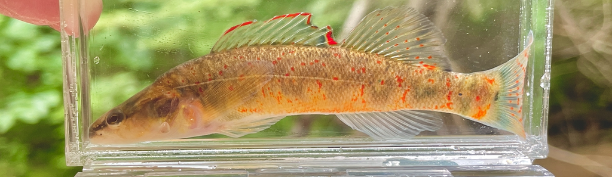

In this week of Landscape genetics we will familiarize ourselves with common genetic diversity analyses using the Kentucky Arrow Darter set used in Blanton et al 2019.

First we will load in the neccesary packages:

```r
library(adegenet)
library(gstudio)
library(LandGenCourse)
library(tibble)
library(here)
library(vcfR)
library(pinfsc50)
library(utils)
```

Next, we will need to load in the Kentucky Arrow Darter genetic data.

```r
kad_data <- read.csv("~/Desktop/landscape_genetics_2022/labs/landgen_lab2_geneticdiversity/kad_dataset.csv")
```

## A. Re-create genind object

```r
Kad.genind <- df2genind(X=kad_data[,c(3:13)], sep=":", ncode=NULL, ind.names= kad_data$Useful_ID, loc.names=NULL, pop=kad_data$Population_ID, NA.char="NA", ploidy=2, type="codom", strata=NULL, hierarchy=NULL)

Kad.genind
```

```
## /// GENIND OBJECT /////////
##
##  // 213 individuals; 11 loci; 117 alleles; size: 138.6 Kb
##
##  // Basic content
##    @tab:  213 x 117 matrix of allele counts
##    @loc.n.all: number of alleles per locus (range: 3-31)
##    @loc.fac: locus factor for the 117 columns of @tab
##    @all.names: list of allele names for each locus
##    @ploidy: ploidy of each individual  (range: 2-2)
##    @type:  codom
##    @call: df2genind(X = kad_data[, c(3:13)], sep = ":", ncode = NULL, ind.names = kad_data$Useful_ID,
##     loc.names = NULL, pop = kad_data$Population_ID, NA.char = "NA",
##     ploidy = 2, type = "codom", strata = NULL, hierarchy = NULL)
##
##  // Optional content
##    @pop: population of each individual (group size range: 9-31)
```

## B. Check that markers are polymorphic

```r
summary(Kad.genind)
```

```
##
## // Number of individuals: 213
## // Group sizes: 24 19 26 24 9 27 14 31 18 21
## // Number of alleles per locus: 5 3 10 8 10 10 10 11 31 16 3
## // Number of alleles per group: 60 29 51 25 14 41 41 44 62 58
## // Percentage of missing data: 2.94 %
## // Observed heterozygosity: 0.3 0.04 0.45 0.42 0.63 0.51 0.7 0.49 0.69 0.6 0.22
## // Expected heterozygosity: 0.54 0.19 0.63 0.55 0.83 0.84 0.88 0.82 0.94 0.88 0.48
```

The output of the summary function shows us the following:

11 loci with 3 - 31 alleles (117 in total) Expected heterozygosity varies between 0.19 and 0.94 There is a small amount of missing values (2.94%)

## C. Check for deviations from Hardy-Weinberg equilibrium (HWE)

For a very large population (no drift) with random mating and non-overlapping generations (plus a few more assumptions about the mating system), and in the absence of mutation, migration (gene flow) and selection, we can predict offspring genotype frequencies from allele frequencies of the parent generation (Hardy-Weinberg equilibrium). In general, we don’t expect all of these assumptions to be met (e.g., if we want to study gene flow or selection, we kind of expect that these processes are present).

Here are p-values for two alternative tests of deviation from HWE for each locus. Columns:

chi^2: value of the classical chi-squared test statistic

df: degrees of freedom of the chi-squared test

Pr(chi^2 >): p-value of the chi-squared test (‘>’ indicates that the alternative is ‘greater,’ which is always the case for a chi-squared test)

Pr.exact: p-value from an exact test based on Monte Carlo permutation of alleles (for diploids only).

The default is B = 1000 permutations (set B = 0 to skip this test). Here we use the function ‘round’ with argument ‘digits = 3’ to round all values to 3 decimals.

```r
round(pegas::hw.test(Kad.genind, B = 1000), digits = 3)
```

```
##         chi^2  df Pr(chi^2 >) Pr.exact
## C2     89.599  10           0        0
## C3    345.456   3           0        0
## C6    323.814  45           0        0
## C117  434.427  28           0        0
## D131  142.252  45           0        0
## C26b  529.005  45           0        0
## Cv12  197.543  45           0        0
## D10   307.827  55           0        0
## D11  1402.630 465           0        0
## D107  591.560 120           0        0
## D116   63.818   3           0        0
```

Both tests suggest that all loci are out of HWE globally (across all 213 individuals).

Next, we check for HWE of each locus in each population.

*Notes on the code: The curly brackets ‘{ }’ below are used to keep the output from multiple lines together in the html file. Function ‘seppop’ splits the genind object by population. We use ‘sapply’ to apply the function ‘hw.test’ from package ‘pegas’ to each population (see this week’s video and tutorial). We set ‘B=0’ to specify that we don’t need any permutations right now. The function ‘t’ takes the transpose of the resulting matrix, which means it flips rows and columns. This works on a matrix, not a data frame, hence we use ‘data.matrix’ to temporarily interpret the data frame as a matrix.*

### Chi-squared test: p-value

```r
HWE.test <- data.frame(sapply(seppop(Kad.genind),
                              function(ls) pegas::hw.test(ls, B=0)[,3]))
HWE.test.chisq <- t(data.matrix(HWE.test))
{cat("Chi-squared test (p-values):", "\n")
round(HWE.test.chisq,3)}
```

```
## Chi-squared test (p-values):
```

```
##        C2    C3    C6  C117  D131  C26b  Cv12   D10   D11  D107  D116
## X1  0.772 1.000 0.285 0.891 0.547 0.889 0.331 0.000 0.959 0.003 0.392
## X2  1.000 0.498 0.243 0.356 0.678 1.000 0.865 0.000 0.000 0.001 1.000
## X3  0.929 1.000 0.980 0.690 0.425 0.430 0.748 0.464 0.452 0.830 0.190
## X4  0.744 1.000 0.744 1.000 0.744 0.484 0.554 0.910 0.741 0.917 1.000
## X5  1.000 0.003 1.000 1.000 0.987 1.000 1.000 1.000 1.000 1.000 1.000
## X6  1.000 0.000 0.640 0.096 0.866 0.048 0.648 0.182 0.488 0.313 0.760
## X7  0.079 1.000 0.033 0.360 0.105 0.110 0.886 0.962 0.030 0.437 0.684
## X8  1.000 0.000 0.000 0.000 0.720 0.655 0.644 0.764 0.927 0.056 1.000
## X9  0.528 0.000 0.017 0.001 0.872 0.637 0.712 0.009 0.552 0.003 0.494
## X10 0.589 0.000 0.007 0.740 0.693 0.873 0.183 0.036 0.000 0.704 0.992
```

Let’s repeat this with a Monte Carlo permutation test with B = 1000 replicates:

### Monte Carlo: p-value

```r
HWE.test <- data.frame(sapply(seppop(Kad.genind),
                              function(ls) pegas::hw.test(ls, B=1000)[,4]))
HWE.test.MC <- t(data.matrix(HWE.test))
{cat("MC permuation test (p-values):", "\n")
round(HWE.test.MC,3)}
```

```
## MC permuation test (p-values):
```

```
##        C2    C3    C6  C117  D131  C26b  Cv12   D10   D11  D107  D116
## X1  0.738 1.000 0.365 1.000 0.439 1.000 0.420 0.000 0.901 0.373 0.696
## X2  1.000 0.643 0.182 0.651 0.621 1.000 1.000 0.021 0.110 0.202 1.000
## X3  0.809 1.000 0.847 0.949 0.088 0.362 0.687 0.151 0.336 0.577 0.193
## X4  1.000 1.000 1.000 1.000 1.000 1.000 0.603 1.000 0.692 1.000 1.000
## X5  1.000 0.059 1.000 1.000 1.000 1.000 1.000 1.000 1.000 1.000 1.000
## X6  1.000 0.000 0.819 0.220 0.370 0.109 0.705 0.076 0.312 0.189 1.000
## X7  0.028 1.000 0.039 0.594 0.068 0.098 0.906 0.816 0.230 0.250 0.780
## X8  1.000 0.000 0.033 0.005 0.862 1.000 0.521 0.655 0.440 0.004 1.000
## X9  0.545 0.025 0.173 0.009 0.760 0.376 0.484 0.020 0.604 0.128 1.000
## X10 0.641 0.000 0.095 1.000 0.699 0.950 0.049 0.207 0.000 0.856 1.000
```

We write the results into a data frame ‘Prop.loci.out.of.HWE’ and use ‘=’ to specify the name for each column.

```r
alpha=0.05
Prop.loci.out.of.HWE <- data.frame(Chisq=apply(HWE.test.chisq<alpha, 2, mean),
           MC=apply(HWE.test.MC<alpha, 2, mean))
Prop.loci.out.of.HWE
```

```
##      Chisq  MC
## C2     0.0 0.1
## C3     0.5 0.4
## C6     0.4 0.2
## C117   0.2 0.2
## D131   0.0 0.0
## C26b   0.1 0.0
## Cv12   0.0 0.1
## D10    0.4 0.3
## D11    0.3 0.1
## D107   0.3 0.1
## D116   0.0 0.0
```

And similarly, for each population, the proportion of loci that were out of HWE:

```r
Prop.pops.out.of.HWE <- data.frame(Chisq=apply(HWE.test.chisq<alpha, 1, mean),
           MC=apply(HWE.test.MC<alpha, 1, mean))
Prop.pops.out.of.HWE
```

```
##          Chisq         MC
## X1  0.18181818 0.09090909
## X2  0.27272727 0.09090909
## X3  0.00000000 0.00000000
## X4  0.00000000 0.00000000
## X5  0.09090909 0.00000000
## X6  0.18181818 0.09090909
## X7  0.18181818 0.18181818
## X8  0.27272727 0.36363636
## X9  0.45454545 0.27272727
## X10 0.36363636 0.27272727
```

The results suggest that:

While most loci are out of HWE globally, this is largely explained by subdivision (variation in allele frequencies among local populations indicating limited gene flow). No locus is consistently out of HWE across populations (loci probably not affected by selection). Some populations are somewhat consistently out of HWE across loci, indicating possible recent major bottlenecks/ founder effects (Populations 9 and 10).

```r
Chisq.fdr <- matrix(p.adjust(HWE.test.chisq,method="fdr"),
                    nrow=nrow(HWE.test.chisq))
MC.fdr <- matrix(p.adjust(HWE.test.MC, method="fdr"),
                    nrow=nrow(HWE.test.MC))

Prop.pops.out.of.HWE <- data.frame(Chisq=apply(HWE.test.chisq<alpha, 1, mean),
           MC=apply(HWE.test.MC<alpha, 1, mean),
           Chisq.fdr=apply(Chisq.fdr<alpha, 1, mean),
           MC.fdr=apply(MC.fdr<alpha, 1, mean))
Prop.pops.out.of.HWE
```

```
##          Chisq         MC  Chisq.fdr     MC.fdr
## X1  0.18181818 0.09090909 0.18181818 0.09090909
## X2  0.27272727 0.09090909 0.27272727 0.00000000
## X3  0.00000000 0.00000000 0.00000000 0.00000000
## X4  0.00000000 0.00000000 0.00000000 0.00000000
## X5  0.09090909 0.00000000 0.09090909 0.00000000
## X6  0.18181818 0.09090909 0.09090909 0.09090909
## X7  0.18181818 0.18181818 0.00000000 0.00000000
## X8  0.27272727 0.36363636 0.27272727 0.09090909
## X9  0.45454545 0.27272727 0.27272727 0.00000000
## X10 0.36363636 0.27272727 0.27272727 0.18181818
```

## D. Check for linkage disequilibrium (LD)

For microsatellite markers, we typically don’t know where on the genome they are located. The closer together two markers are on a chromosome, the more likely they are inherited together, which means that they don’t really provide independent information. Testing for linkage disequilibrium assesses this, for each pair of loci, by checking whether alleles of two loci are statistically associated.

This step is especially important when developing a new set of markers. You may want to drop (the less informative) one marker of any pair of linked loci.

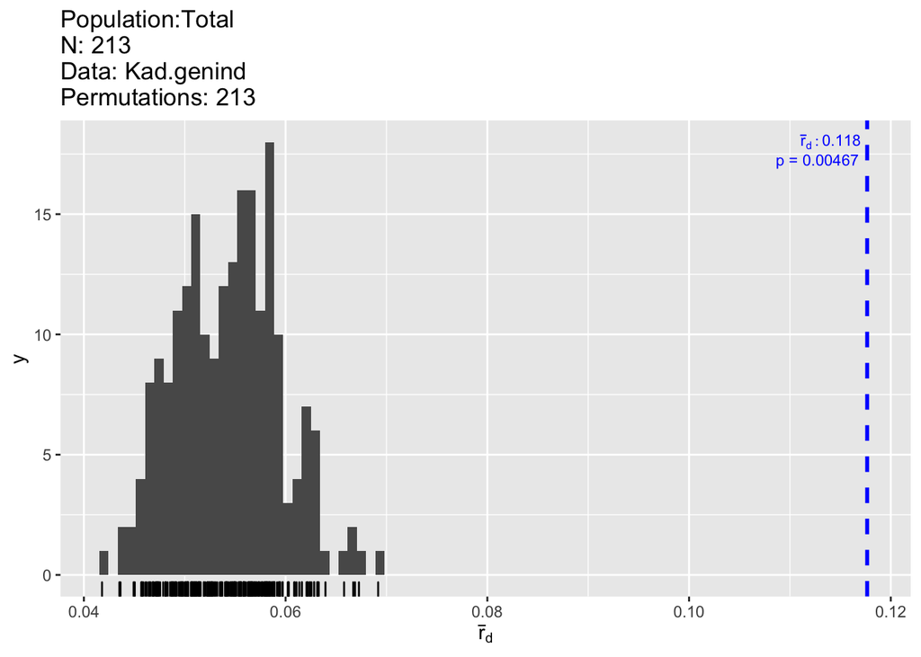

```
##          Ia        p.Ia       rbarD        p.rD
## 1.154575532 0.004672897 0.117657897 0.004672897
```

```r
poppr::ia(Kad.genind, sample=213)
```

```r
LD.pair <- poppr::pair.ia(Kad.genind)
```

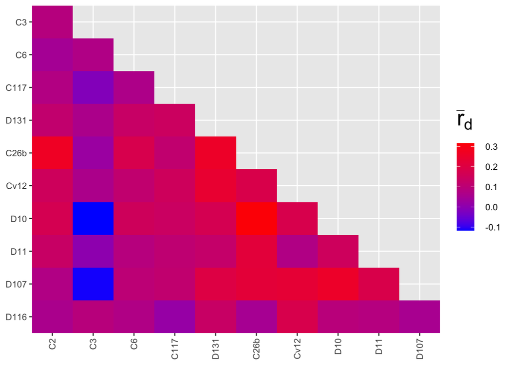

```r
LD.pair
```

```
##                Ia   rbarD
## C2:C3      0.0850  0.0853
## C2:C6      0.0461  0.0463
## C2:C117    0.0787  0.0788
## C2:D131    0.1148  0.1166
## C2:C26b    0.2626  0.2650
## C2:Cv12    0.1495  0.1496
## C2:D10     0.1711  0.1712
## C2:D11     0.1162  0.1331
## C2:D107    0.0749  0.0750
## C2:D116    0.0589  0.0589
## C3:C6      0.0733  0.0733
## C3:C117   -0.0152 -0.0153
## C3:D131    0.0625  0.0628
## C3:C26b    0.0245  0.0245
## C3:Cv12    0.0630  0.0630
## C3:D10    -0.1169 -0.1170
## C3:D11     0.0039  0.0043
## C3:D107   -0.1126 -0.1136
## C3:D116    0.0884  0.0889
## C6:C117    0.0664  0.0665
## C6:D131    0.1312  0.1318
## C6:C26b    0.1781  0.1783
## C6:Cv12    0.1143  0.1144
## C6:D10     0.1518  0.1521
## C6:D11     0.0781  0.0859
## C6:D107    0.0995  0.1005
## C6:D116    0.0723  0.0728
## C117:D131  0.1422  0.1434
## C117:C26b  0.1136  0.1140
## C117:Cv12  0.1513  0.1513
## C117:D10   0.1390  0.1390
## C117:D11   0.0973  0.1089
## C117:D107  0.1131  0.1137
## C117:D116  0.0186  0.0186
## D131:C26b  0.2578  0.2580
## D131:Cv12  0.2358  0.2381
## D131:D10   0.1697  0.1715
## D131:D11   0.1156  0.1229
## D131:D107  0.1933  0.1985
## D131:D116  0.1302  0.1329
## C26b:Cv12  0.1850  0.1858
## C26b:D10   0.3152  0.3168
## C26b:D11   0.2025  0.2185
## C26b:D107  0.2181  0.2220
## C26b:D116  0.0489  0.0495
## Cv12:D10   0.1811  0.1811
## Cv12:D11   0.0657  0.0737
## Cv12:D107  0.2285  0.2295
## Cv12:D116  0.1802  0.1806
## D10:D11    0.1321  0.1488
## D10:D107   0.2548  0.2557
## D10:D116   0.0912  0.0914
## D11:D107   0.1566  0.1840
## D11:D116   0.0720  0.0835
## D107:D116  0.0545  0.0545
```

The strongest correlation is around 0.3, for markers C26b and D10.

## E. Check for null alleles

One potential drawback for microsatellites as molecular markers is the presence of null alleles that fail to amplify, thus they couldn’t be detected in the PCR assays.

The function ‘null.all’ takes a genind object and returns a list with two components (‘homozygotes’ and ‘null.allele.freq’), and each of these is again a list. See ‘?null.all’ for details and choice of method.

#### List ‘homozygotes’:

homozygotes$observed: observed number of homozygotes for each allele at each locus

homozygotes$bootstrap: distribution of the expected number of homozygotes

homozygotes$probability.obs: probability of observing the number of homozygotes

*Note: we are turning off warnings here (currently the code throws a warning for each sample, though results don’t seem to be affected).*

```r
Null.alleles <- PopGenReport::null.all(Kad.genind)
Null.alleles$homozygotes$probability.obs
```

```
##      Allele-1 Allele-2 Allele-3 Allele-4 Allele-5 Allele-6 Allele-7 Allele-8
## C2      0.000    0.000    0.000    0.015    0.006       NA       NA       NA
## C3      0.000    0.000    0.000       NA       NA       NA       NA       NA
## C6      0.006    0.001    0.014    0.018    0.009    0.019    0.000    0.000
## C117    0.030    0.523    0.003    0.000    0.000    0.000    0.011    0.000
## D131    0.001    0.001    0.002    0.003    0.031    0.000    0.007    0.088
## C26b    0.000    0.246    0.000    0.056    0.332    0.000    0.000    0.000
## Cv12    0.168    0.000    0.094    0.003    0.387    0.003    0.000    0.011
## D10     0.000    0.001    0.000    0.024    0.000    0.319    0.011    0.001
## D11     0.007    0.019    0.017    0.125    0.006    0.005    0.029    0.033
## D107    0.057    0.002    0.000    0.000    0.001    0.268    0.000    0.003
## D116    0.000    0.000    0.010       NA       NA       NA       NA       NA
##      Allele-9 Allele-10 Allele-11 Allele-12 Allele-13 Allele-14 Allele-15
## C2         NA        NA        NA        NA        NA        NA        NA
## C3         NA        NA        NA        NA        NA        NA        NA
## C6      0.003     0.006        NA        NA        NA        NA        NA
## C117       NA        NA        NA        NA        NA        NA        NA
## D131    0.002     0.008        NA        NA        NA        NA        NA
## C26b    0.051     0.000        NA        NA        NA        NA        NA
## Cv12    0.252     0.000        NA        NA        NA        NA        NA
## D10     0.000     0.000     0.002        NA        NA        NA        NA
## D11     0.001     0.000     0.007     0.044     0.012     0.037     0.009
## D107    0.026     0.001     0.000     0.094     0.000     0.022     0.001
## D116       NA        NA        NA        NA        NA        NA        NA
##      Allele-16 Allele-17 Allele-18 Allele-19 Allele-20 Allele-21 Allele-22
## C2          NA        NA        NA        NA        NA        NA        NA
## C3          NA        NA        NA        NA        NA        NA        NA
## C6          NA        NA        NA        NA        NA        NA        NA
## C117        NA        NA        NA        NA        NA        NA        NA
## D131        NA        NA        NA        NA        NA        NA        NA
## C26b        NA        NA        NA        NA        NA        NA        NA
## Cv12        NA        NA        NA        NA        NA        NA        NA
## D10         NA        NA        NA        NA        NA        NA        NA
## D11      0.003     0.032     0.022         0     0.056     0.099         0
## D107     0.001        NA        NA        NA        NA        NA        NA
## D116        NA        NA        NA        NA        NA        NA        NA
##      Allele-23 Allele-24 Allele-25 Allele-26 Allele-27 Allele-28 Allele-29
## C2          NA        NA        NA        NA        NA        NA        NA
## C3          NA        NA        NA        NA        NA        NA        NA
## C6          NA        NA        NA        NA        NA        NA        NA
## C117        NA        NA        NA        NA        NA        NA        NA
## D131        NA        NA        NA        NA        NA        NA        NA
## C26b        NA        NA        NA        NA        NA        NA        NA
## Cv12        NA        NA        NA        NA        NA        NA        NA
## D10         NA        NA        NA        NA        NA        NA        NA
## D11      0.001         0         0     0.003     0.035     0.001      0.03
## D107        NA        NA        NA        NA        NA        NA        NA
## D116        NA        NA        NA        NA        NA        NA        NA
##      Allele-30 Allele-31
## C2          NA        NA
## C3          NA        NA
## C6          NA        NA
## C117        NA        NA
## D131        NA        NA
## C26b        NA        NA
## Cv12        NA        NA
## D10         NA        NA
## D11          0     0.001
## D107        NA        NA
## D116        NA        NA
```

#### List ‘null.allele.freq’:

null.allele.freq$summary1: null allele frequency estimates based upon the forumulas of Chakraborty et al. (1994)

null.allele.freq$summary2: null allele frequency estimates based upon the forumulas of Brookfield (1996)

we will use summary one since we have individuals missing both alleles?

```r
{cat(" summary1 (Chakraborty et al. 1994):", "\n")
round(Null.alleles$null.allele.freq$summary1,2)}
```

```
##  summary1 (Chakraborty et al. 1994):
```

```
##                      C2   C3   C6 C117 D131 C26b Cv12  D10  D11 D107 D116
## Observed frequency 0.29 0.66 0.16 0.13 0.14 0.25 0.11 0.25 0.15 0.19 0.37
## Median frequency   0.29 0.66 0.16 0.13 0.14 0.24 0.11 0.25 0.15 0.19 0.37
## 2.5th percentile   0.21 0.47 0.10 0.07 0.09 0.18 0.07 0.19 0.11 0.14 0.27
## 97.5th percentile  0.38 0.85 0.24 0.20 0.18 0.31 0.17 0.31 0.20 0.24 0.48
```

```r
{cat("summary2 (Brookfield et al. 1996):", "\n")
round(Null.alleles$null.allele.freq$summary2,2)}
```

```
## summary2 (Brookfield et al. 1996):
```

```
##                      C2   C3   C6 C117 D131 C26b Cv12  D10  D11 D107 D116
## Observed frequency 0.19 0.14 0.12 0.09 0.12 0.22 0.11 0.22 0.15 0.17 0.21
## Median frequency   0.19 0.14 0.12 0.09 0.12 0.22 0.11 0.22 0.14 0.17 0.21
## 2.5th percentile   0.13 0.09 0.07 0.05 0.08 0.16 0.07 0.17 0.11 0.13 0.16
## 97.5th percentile  0.25 0.20 0.18 0.13 0.16 0.28 0.15 0.27 0.19 0.22 0.27
```

For this example, both methods suggest that there may be null alleles in most loci. However, the estimates of the frequency of null alleles differ a lot between the two methods.

## F. Overall interpretation

####Spatial genetic structure:

The Kentucky Arrow Darter data used in this lab includes a great deal of genetic structure.

#### HWE:

Therefore, we expect global estimates (i.e., the whole dataset) of He to be out of HWE due to population substructure (HWE assumes panmictic populations). We would also expect data to be out of HWE when analyzing data by populations due to population substructure. We could, then, test HWE and linkage disequilibrium at the population level.

####Linkage: The smaller samples sizes we have can result in deviations from HWE and in linkage disequilibrium as an artifact of sample size and/or breeding structure (if one male is responsible for all breeding, his genes would appear “linked” in offspring genotypes, even though they are not physically linked in the genome).

### Null alleles:

Missing data can imply null (non-amplifying) alleles. In this case, while there are loci that have higher “drop-out” rates than others, this is more likely due to some loci being more difficult to call. In addition, some of the samples used in this study were smaller fin clips with lower yields of DNA, resulting in incomplete genotypes. While presence of null alleles is a possibility, genetic structure, breeding patterns at low population size and aggressive quality control of genotypes can all explain the results. Finally, with all of the structure in these data, there are examples at population level of unique alleles that are fixed or nearly fixed.

# Assess genetic diversity

These measures are typically quantified per population.

## A. Rarefied allelic richness

Both nominal sample size (number of fish sampled) and valid sample size (e.g., for each locus, the number of fish with non-missing genetic data) vary between sites. We would expect the number of alleles found in a population to increase with the number of individuals genotyped.

We can check this by plotting the number of alleles against sample size. Here we create an object ‘Sum’ that contains the summary of the genind object, then we can access its elements by ‘$’ to plot what we need. The function ‘names’ lists the names of the elements, which reduced the guesswork.

```r
Sum <- summary(Kad.genind)
names(Sum)
```

```
## [1] "n"         "n.by.pop"  "loc.n.all" "pop.n.all" "NA.perc"   "Hobs"
## [7] "Hexp"
```

We add a regression line to the scatterplot with the function ‘abline,’ where we specify the linear regression model with the function ‘lm.’ In this case, we model the response ‘pop.n.all’ as a function of predictor ‘n.by.pop.’

The barchart (left) shows that there is considerable variation among populations in the number of alleles observed across all loci. The scatterplot (right) with the red regression line shows that the number of alleles increases with sample size.

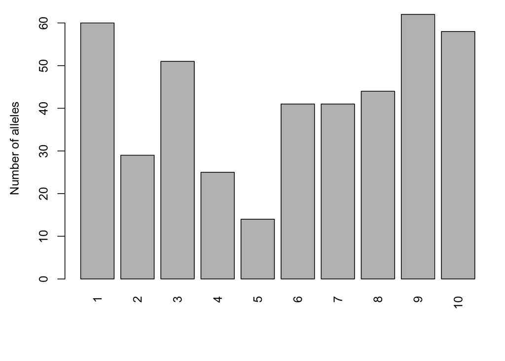

```r
par(mar=c(5.5, 4.5,1,1))
barplot(Sum$pop.n.all, las=3,
       xlab = "", ylab = "Number of alleles")
```

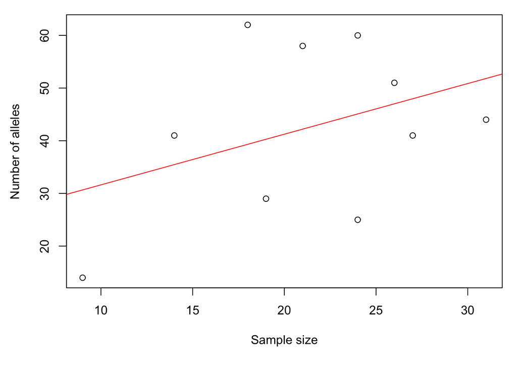

```r
plot(Sum$n.by.pop, Sum$pop.n.all,
       xlab = "Sample size", ylab = "Number of alleles")
abline(lm(Sum$pop.n.all ~ Sum$n.by.pop), col = "red")
```

Hence we should not compare the number of alleles directly. Instead, we’ll use rarefied allelic richness (Ar).

```r
Richness <- PopGenReport::allel.rich(Kad.genind, min.alleles = NULL)
Richness$alleles.sampled
```

```
## [1] 10
```

Populations with more alleles are resampled to determine the average allelic richness among the minimum number of alleles. Here, this means that 10 alleles are sampled from each population, allelic richness is calculated, and the process is repeated many times to determine the average).

Let’s plot the results again. The barchart shows that there is considerable variation in genetic diversity among ponds. The scatterplot against sample size (here: for each population, the average number of valid alleles across loci) suggests that the variation is not as realted to sample size as in the first plot above. The regression line (red) is becoming more horizontal and the range on the y axis has decreased by a lot.

Here we plot the average Ar across loci, so that the result does not depend on the number of loci used.

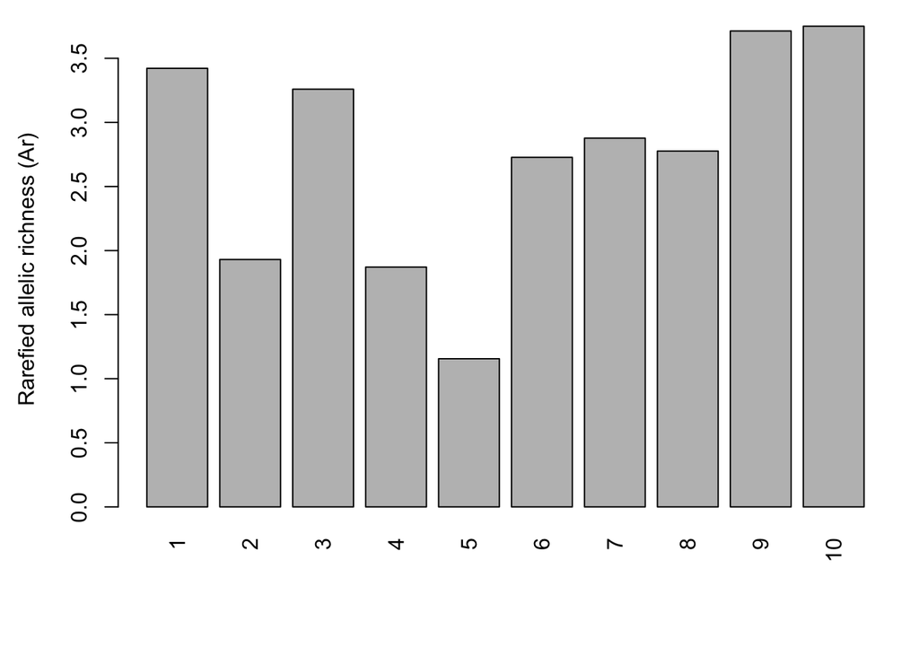

```r
par(mar=c(5.5, 4.5,1,1))
barplot(Richness$mean.richness, las=3, ylab="Rarefied allelic richness (Ar)")
```

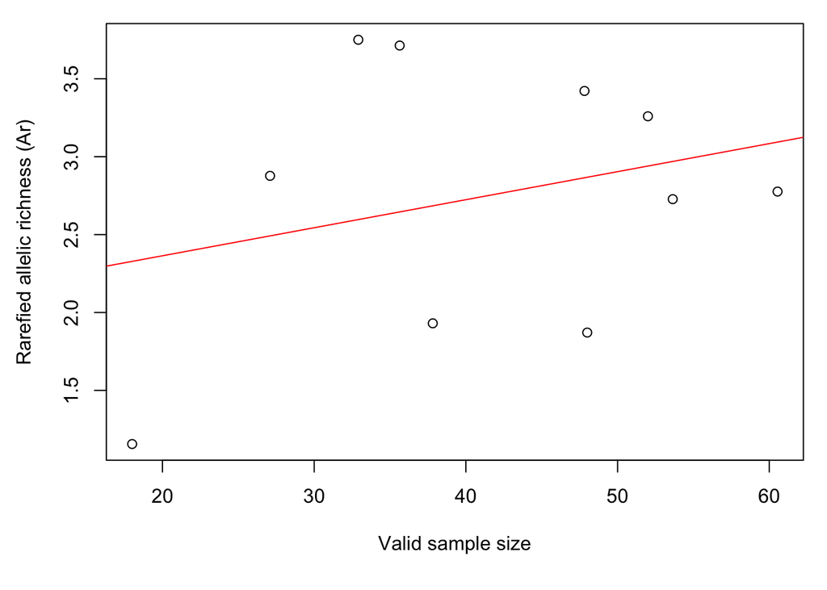

```r
plot(colMeans(Richness$pop.sizes), Richness$mean.richness,
     xlab="Valid sample size",
     ylab="Rarefied allelic richness (Ar)")
abline(lm(Richness$mean.richness ~ colMeans(Richness$pop.sizes)), col="red")
```

## B. Observed and expected heterozygosity

*Note: Writing the ‘genind’ summary into an object ‘Sum’ allows accessing its attributes by name.*

```r
  Sum <- summary(Kad.genind)
  names(Sum)
```

```
## [1] "n"         "n.by.pop"  "loc.n.all" "pop.n.all" "NA.perc"   "Hobs"
## [7] "Hexp"
```

Expected heterozygosity (here: Hexp) is the heterozygosity expected in a population under HWE, and observed heterozygosity (here: Hobs) is the observed number of heterozygotes at a locus divided by the total number of genotyped individuals. Here are the global values (pooled across all populations):

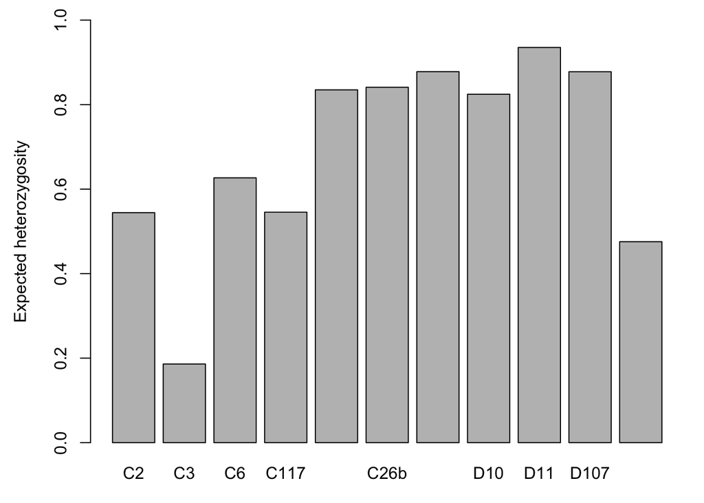

```r
par(mar=c(3, 4.5,1,1))
  barplot(Sum$Hexp, ylim=c(0,1), ylab="Expected heterozygosity")
```

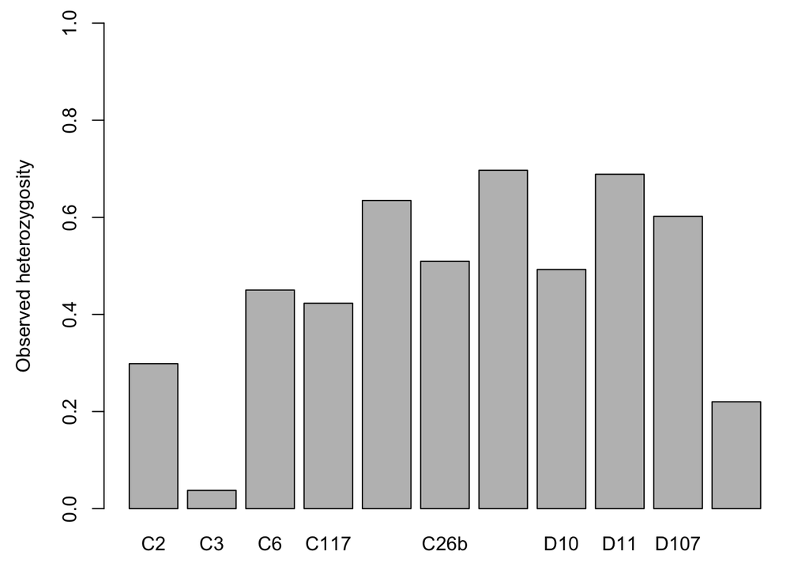

```r
  barplot(Sum$Hobs, ylim=c(0,1), ylab="Observed heterozygosity")
```

By locus and population:

*Here we use ‘seppop’ to split the genind object by population, then ‘sapply’ to apply function ‘summary’ to each population.*

```r
Hobs <- t(sapply(seppop(Kad.genind), function(ls) summary(ls)$Hobs))
  Hexp <- t(sapply(seppop(Kad.genind), function(ls) summary(ls)$Hexp))
  {cat("Expected heterozygosity (Hexp):", "\n")
  round(Hexp, 2)
  cat("\n", "Observed heterozygosity (Hobs):", "\n")
  round(Hobs, 2)}
```

```
## Expected heterozygosity (Hexp):
##
##  Observed heterozygosity (Hobs):
```

```
##      C2   C3   C6 C117 D131 C26b Cv12  D10  D11 D107 D116
## 1  0.54 0.00 0.71 0.62 0.71 0.50 0.92 0.29 0.92 0.78 0.58
## 2  0.00 0.42 0.53 0.58 0.42 0.00 0.47 0.00 0.21 0.74 0.00
## 3  0.46 0.00 0.50 0.69 0.73 0.73 0.73 0.42 0.88 0.77 0.23
## 4  0.46 0.00 0.12 0.00 0.46 0.25 0.67 0.54 0.83 0.04 0.00
## 5  0.00 0.00 0.00 0.00 0.22 0.00 0.00 0.00 0.00 0.00 0.00
## 6  0.00 0.00 0.63 0.30 0.52 0.67 0.89 0.54 0.70 0.77 0.11
## 7  0.36 0.00 0.21 0.57 0.64 0.64 0.71 0.75 0.79 0.64 0.57
## 8  0.00 0.00 0.29 0.19 0.90 0.48 0.71 0.63 0.65 0.52 0.00
## 9  0.82 0.00 0.56 0.83 0.61 0.67 0.67 0.78 0.83 0.88 0.28
## 10 0.40 0.00 0.68 0.44 0.81 0.89 0.69 0.87 0.60 0.80 0.56
```

Let’s plot the average across all loci for each population:

Here we use ‘apply’ to apply the function ‘mean’ to the rows (MARGIN = 1). For columns, use ‘MARGIN = 2.’

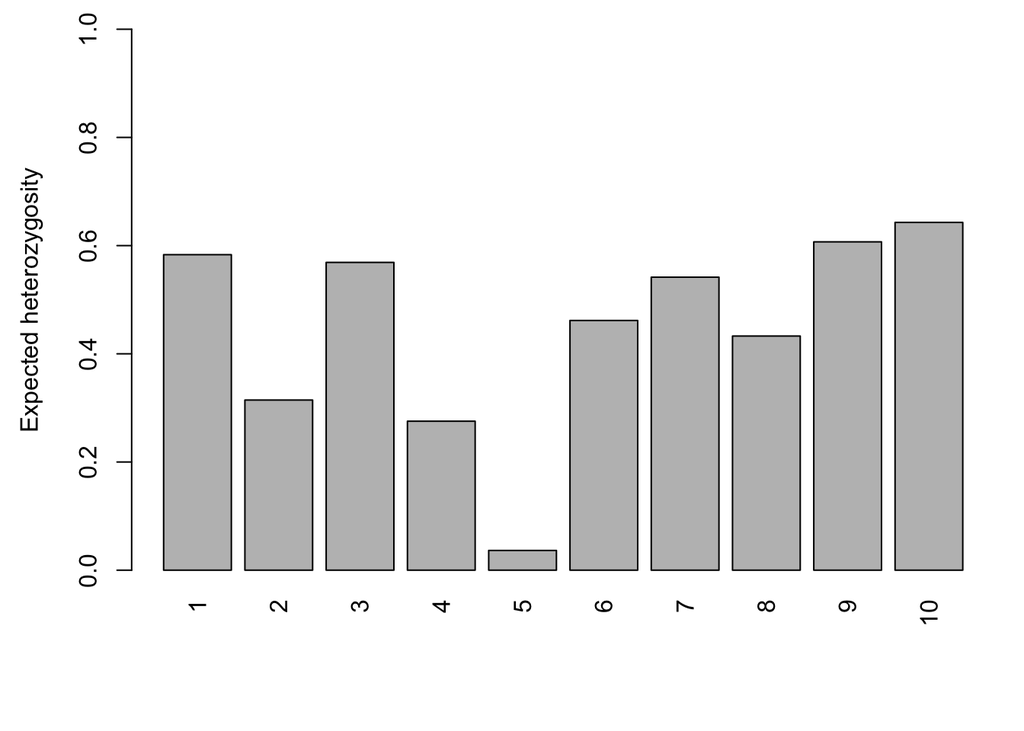

```r
par(mar=c(5.5, 4.5, 1, 1))
  Hobs.pop <- apply(Hobs, MARGIN = 1, FUN = mean)
  Hexp.pop <- apply(Hexp, 1, mean)
  barplot(Hexp.pop, ylim=c(0,1), las=3, ylab="Expected heterozygosity")
```

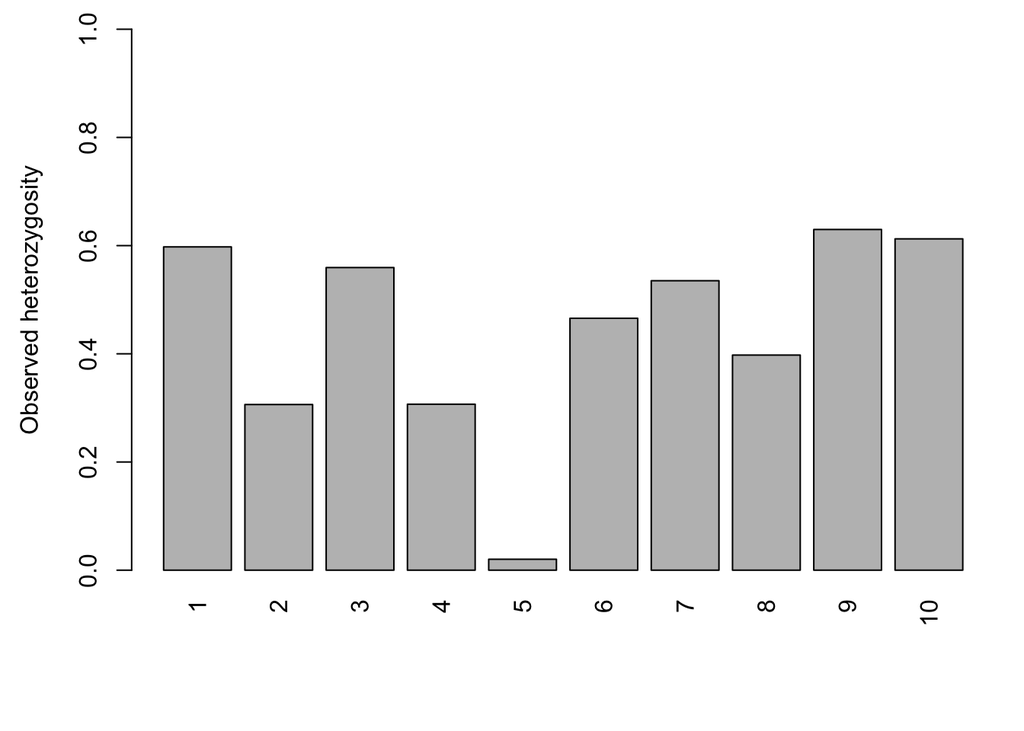

```r
  barplot(Hobs.pop, ylim=c(0,1), las=3, ylab="Observed heterozygosity")
```

## C. Create table with sitel-level genetic diversity measures

```r
Kad.diversity <- data.frame(Pop = names(Hobs.pop),
                              n = Sum$n.by.pop,
                              Hobs = Hobs.pop,
                              Hexp = Hexp.pop,
                              Ar = Richness$mean.richness)
Kad.diversity
```

```
##    Pop  n       Hobs       Hexp       Ar
## 1    1 24 0.59766140 0.58324965 3.421913
## 2    2 19 0.30622010 0.31453035 1.930518
## 3    3 26 0.55944056 0.56898870 3.259311
## 4    4 24 0.30681818 0.27541035 1.871246
## 5    5  9 0.02020202 0.03647587 1.155860
## 6    6 27 0.46568247 0.46162692 2.727438
## 7    7 14 0.53512397 0.54164116 2.877023
## 8    8 31 0.39762952 0.43281840 2.776163
## 9    9 18 0.62982769 0.60697080 3.713312
## 10  10 21 0.61251176 0.64287164 3.750409
```

You can save the R object ‘Kad.diversity’ with the code below

```r
require(here)
if(!dir.exists(paste0(here(),"/output"))) dir.create(paste0(here(),"/output"))
save(Kad.diversity, file = paste0(here(),"/output/Kad.diversity.RData"))
load(paste0(here(),"/output/Kad.diversity.RData"))
```

# Aggregate genetic data at population level (allele frequencies)

For some analyses, we will need to aggregate data from the individual to the population level, e.g. as a table of allele frequencies per population.

Here we convert the ‘genind’ object to a ‘genpop’ object (NOT the same as a ‘genepop’ object!). This is defined in the package ‘adegenet’ to hold population-level genetic data. The function ‘genind2genpop’ obviously converts from ‘genind’ to ‘genpop.’

```r
Kad.genpop <- adegenet::genind2genpop(Kad.genind)
```

```
##
##  Converting data from a genind to a genpop object...
##
## ...done.
```

The function ‘makefreq’ extracts the table with allele frequencies from the ‘genpop’ object. We’ll plot just a few lines and alleles.

```r
Freq <- adegenet::makefreq(Kad.genpop)
```

```
##
##  Finding allelic frequencies from a genpop object...
##
## ...done.
```

```r
round(Freq[1:6,1:10], 2)
```

```
##   C2.141 C2.145 C2.133 C2.129 C2.148 C3.214 C3.210 C3.212 C6.272 C6.280
## 1   0.38   0.56   0.06      0      0   1.00   0.00      0   0.40   0.42
## 2   0.00   1.00   0.00      0      0   0.53   0.47      0   0.68   0.00
## 3   0.67   0.29   0.04      0      0   1.00   0.00      0   0.42   0.00
## 4   0.31   0.00   0.69      0      0   1.00   0.00      0   0.06   0.00
## 5   1.00   0.00   0.00      0      0   0.89   0.11      0   0.00   0.00
## 6   1.00   0.00   0.00      0      0   0.89   0.11      0   0.19   0.00
```

```r
apply(Freq, MARGIN = 1, FUN = sum)    # Just checking
```

```
##  1  2  3  4  5  6  7  8  9 10
## 11 11 11 11 11 11 11 11 11 11
```